# Final Exam Replacement Report

Hasibullah Mahmood

5/24/2020

## Project Description

- Name and Surname
- Gender
- Faculty
- Class
- Citizenship
- And Date of birth

The quiz contained 10 questions with multiple choice, each correct answer 10 point. The questions are listed below:  
Note: As special Turkish characters are not supported by R-Markdown, they are replaced with the similar characters in English.

1. COVID-19 nasil bulasir?
   - Temiz olmayan su ve hava yoluyla bulasir
   - Virus hasta bireylerden oksurme, hapsirma yoluyla ortaya sacilan damlaciklarla bulasabilir
   - Temiz alanlardan ve hayvanlar yoluyla bulasir
   - Yukaridakilerden hepsi
2. COVID-19’un yaygin semptomlari nelerdir?
   - Yorgunluk
   - Ates
   - Kuru oksuruk
   - Hepsi
3. Her zaman birinin COVID-19 olup olmadigini soyleyebilir misiniz?
   - Hayir- bireyin COVID-19 semptomlari gosterilmeyebilir ama cok iyi bir Tasiyici olabilir
   - Evet - bireyin geldigi ulke’den, irkini ve etnik kokenin yoluyla soyleyebilir
   - Evet - COVID-19 olan hastalar cok oksuruyorlar
   - Hicbiri
4. Ellerimizi nasil KOVID 19’dan koruyabiliriz?
   - Sabun ve su ile yikamak
   - yanliz su ile yikamak
   - Yikanmadan yalniz Kagit mendil ve ya bez ile silmek
   - Sabun ve su ile yikamak ve en az 20 saniye ovalamak
5. Asagidakilerden kimler COVID-19 Enfeksiyonun riskli gruptadir? (tum dogru yanitlari secin)
   - cocuklar
   - Yaslilar - ozellikle 60 yas ustu olanlar
   - Sigara icenler
   - Kronik hastaligi var olanlar
6. COVID-19’un kesin tedavisi var mi?
   - Evet - Sicak icecekler COVID-19’u iyilestirebilir
   - Hayir - COVID-19 bir olum cezasidir
   - Hayir- ama cogu insan (yaklasik %80) ozel tedaviye ihtiyac duymadan hastaliktan iyilesir.
7. Asagidakilerden hangisi fiziksel mesafeye bir ornektir?
   - Kalabalik yerlere gitmemek ve yakinlarimizin evlerine ziyaret etmemek
   - Birlikte yasadiginiz insanlarla konusmayi birakmak
   - Telefon yoluyla arkadaslarinizla konusmamak
   - Ailedeki herkes kendi odasinda salgin bitmesine kadar karantinada kalmak
8. Dogru veya Yanlis: ABD’de 35 yasin altindaki insanlar koronavirus ile enfekte olabilir ve hastalanabilir, ancak bu yas grubunda genc yetiskinlerin COVID olumleri bildirilmemistir.
   - Dogru
   - Yanlis
9. supheli veya teyit edilmis COVID-19’dan olan kisilerin cesetlerini yok etmek guvenli yontemi nedir?
   - oluleri yakmak
   - kimyasal madde kullanmadan Defnetmek
   - SoNMus KIREC (KALSIYUM HIDROKSIT) ile defnetmek
   - Yukaridakilerden hicbiri
10. COVID-19 icin bugune kadar asi gelistirildi mi?
    - Evet
    - Hayir

## Importing the relevant libraries

```r
library(ggplot2)
library(dplyr)
library(GGally)
library(car)
```

## Loading the data

```r
df <- read.csv('data.csv')
head(df, n=3)
```

```
##             Timestamp Score           Ad.Soyad Cinsiyet               Fakulte
## 1 5/24/2020  31836 AM    60 Ahmad Milad Ahadi     Erkek Muhendislik Fakultesi
## 2 5/24/2020  44056 PM    70      Ahmad orokzai    Erkek      Egitim Fakultesi
## 3 5/24/2020  45459 PM    50              Ahmed    Erkek Muhendislik Fakultesi
##   Sinif     Vatandaslik Dogum.Tarihi
## 1     3 Yabanci Uyruklu    5/31/1995
## 2     4 Yabanci Uyruklu    5/28/1997
## 3     3 Yabanci Uyruklu    7/15/1999
##                                                                   X1.COViD.19.nasil.bulasir.
## 1 Virus hasta bireylerden oksurme, hapsirma yoluyla ortaya sacilan damlaciklarla bulasabilir
## 2 Virus hasta bireylerden oksurme, hapsirma yoluyla ortaya sacilan damlaciklarla bulasabilir
## 3                                                                     Yukaridakilerden hepsi
##   X2.COViD.19.un.yaygin.semptomlari.nelerdir.
## 1                                Kuru oksuruk
## 2                                Kuru oksuruk
```

[output cut: 33 more lines]

## Data visualization and descriptive states

#### Analyzing Quiz Score

```r
summary(df$Score)
```

```
##    Min. 1st Qu.  Median    Mean 3rd Qu.    Max.
##   40.00   60.00   80.00   73.67   90.00  100.00
```

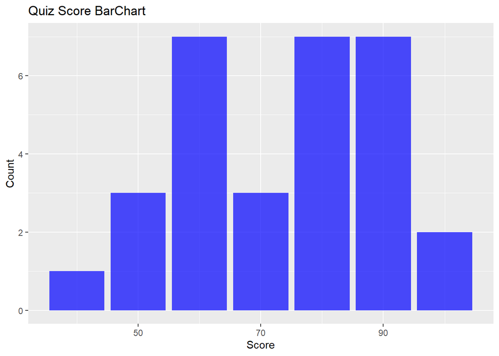

```r
ggplot(data=df, aes(x=Score)) +
  geom_bar(fill="blue", alpha=0.7)+
  labs(title = "Quiz Score BarChart", x="Score", y="Count")
```

As it is written above, average is 73.67/100, median is 80/100 and Range is 40-100 Points.

#### Analyzing Students score based on gender

```r
summary(df[df$Cinsiyet=="Erkek", 2])
```

```
##    Min. 1st Qu.  Median    Mean 3rd Qu.    Max.
##   40.00   60.00   70.00   69.57   80.00  100.00
```

```r
summary(df[df$Cinsiyet=="Kadin", 2])
```

```
##    Min. 1st Qu.  Median    Mean 3rd Qu.    Max.
##   80.00   80.00   90.00   87.14   90.00  100.00
```

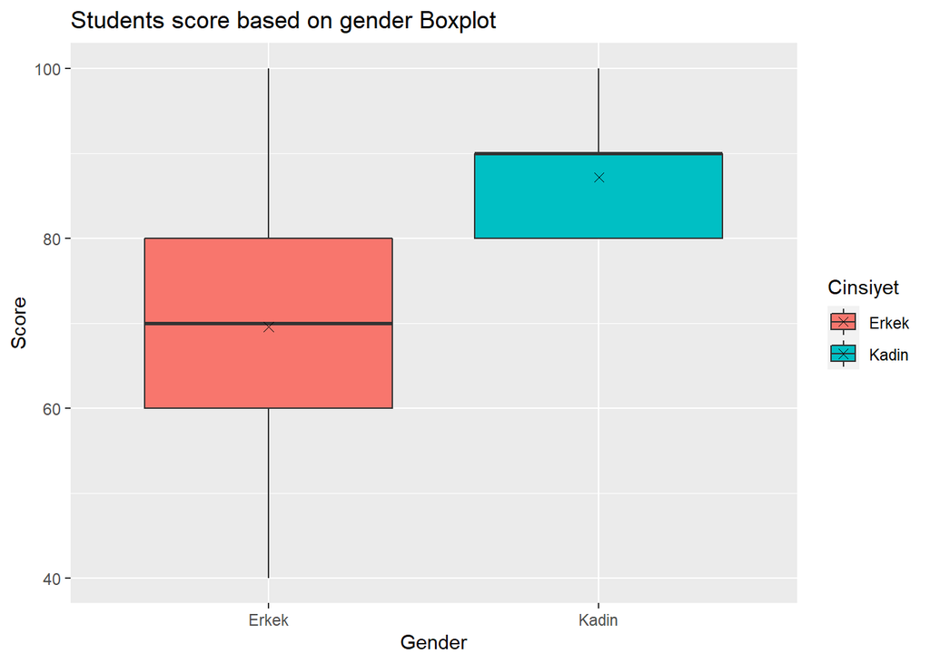

```r
ggplot(data=df, aes(x=Cinsiyet, y=Score, fill= Cinsiyet)) +
  geom_boxplot() +
  labs(title = "Students score based on gender Boxplot", x = "Gender", y="Score") +
  stat_summary(fun=mean, geom="point", shape=4, size=2)
```

Referring to boxplot above, the score for male students is very disperse than the score for female students, and the mean and median of scores for female students are a lot higher than male students. We will test it later to check whether the differences are significant.

#### Analyzing Students Gender

```r
# Cast data-type of gender to factor(nominal)
df$Cinsiyet <- as.factor(df$Cinsiyet)

# Print summary of gender
summary(df$Cinsiyet)
```

```
## Erkek Kadin
##    23     7
```

23 Male and 7 Female students participated in this Quiz.

#### Analyzing Students Faculty based on gender

```r
# Cast data-type of Faculty to factor(nominal)
df$Fakulte <- as.factor(df$Fakulte)

# Print summary of Faculty
summary(df$Fakulte)
```

```
##                     Egitim Fakultesi Iktisadi ve Idari Bilimler Fakultesi
##                                    2                                    4
##                Muhendislik Fakultesi           Saglik Bilimleri Fakultesi
##                                   21                                    2
##                  Teknoloji Fakultesi
##                                    1
```

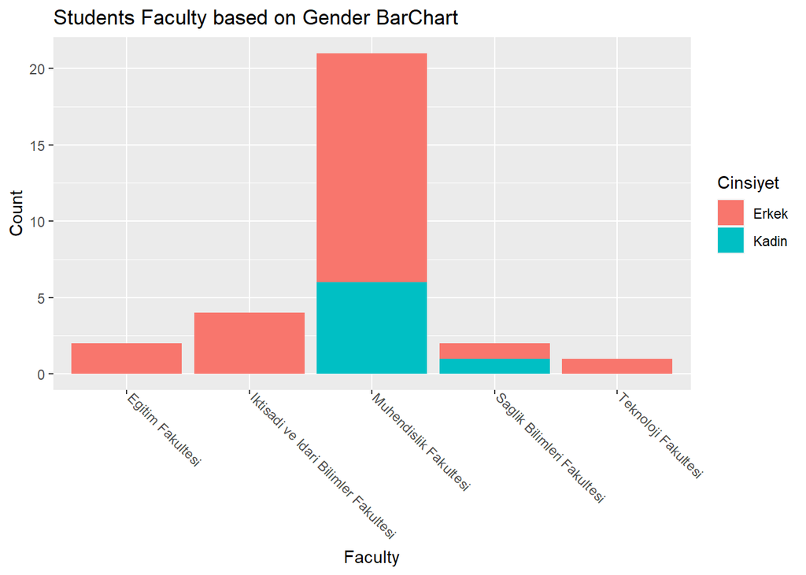

```r
# Graph
ggplot(df, aes(x=Fakulte, fill=Cinsiyet))+
  geom_bar() +
  labs(title = "Students Faculty based on Gender BarChart",x= "Faculty",y= "Count") +
  theme(axis.text.x=element_text(angle=-45,hjust=0,vjust=0))
```

The Graph above indicates most of the students participated in the quiz are Male and from Engineering faculty.

#### Analyzing Score based on Faculty

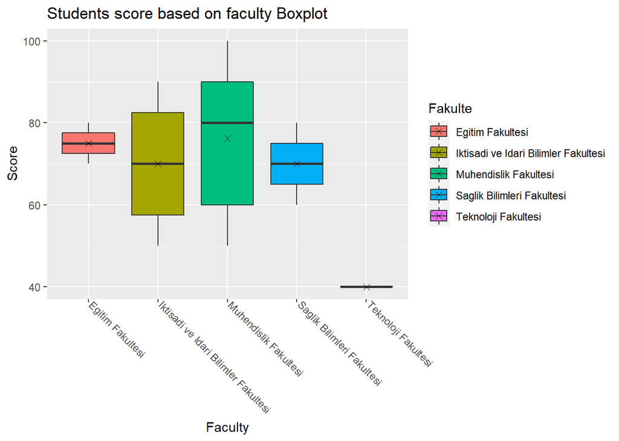

```r
ggplot(data=df, aes(x=Fakulte, y=Score, fill= Fakulte)) +
  geom_boxplot() +
  labs(title = "Students score based on faculty Boxplot", x = "Faculty", y="Score") +
  stat_summary(fun=mean, geom="point", shape=4, size=2) +
  theme(axis.text.x=element_text(angle=-45,hjust=0,vjust=0))
```

The above figure shows, most probably the average of score are equal for all faculties except the technology faculty.

#### Analyzing students class

```r
classes <- data.frame(table(df$Sinif))
names(classes) <- c("class", "freq")
classes
```

```
##   class freq
## 1     1    3
## 2     2   10
## 3     3   11
## 4     4    6
```

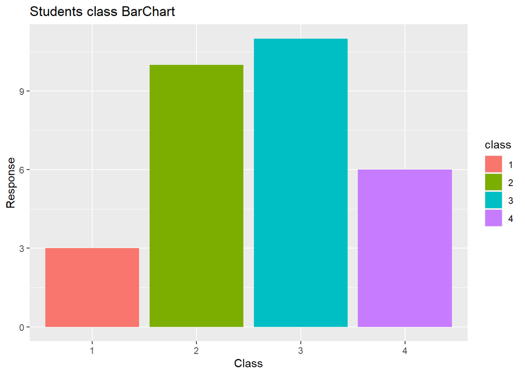

```r
ggplot(classes, aes(x=class, y=freq, fill=class))+
  geom_bar(stat = "identity") +
  labs(title = "Students class BarChart", x="Class", y="Response")
```

The figure indicates most of students are from 3rd class.

#### Analyzing students score based on class

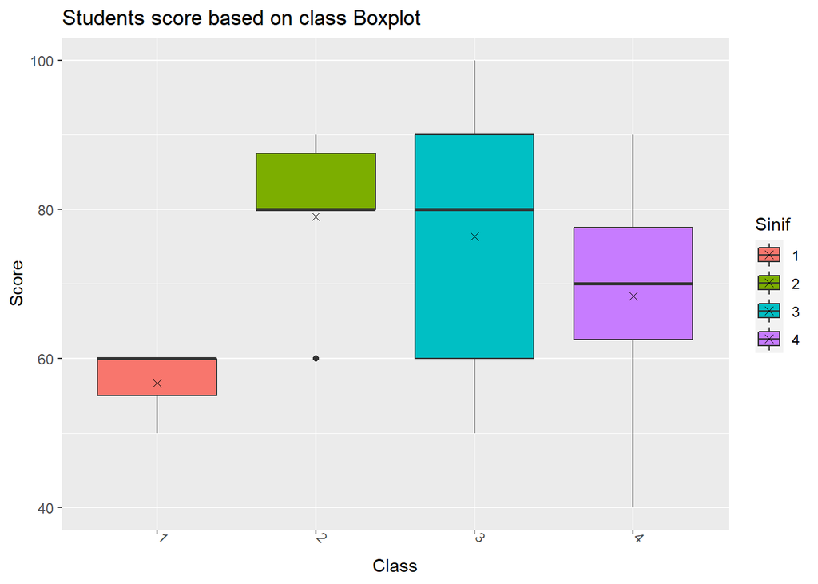

```r
df$Sinif <- as.factor(df$Sinif)

ggplot(data=df, aes(x=Sinif, y=Score, fill= Sinif)) +
  geom_boxplot() +
  labs(title = "Students score based on class Boxplot", x = "Class", y="Score") +
  stat_summary(fun=mean, geom="point", shape=4, size=2) +
  theme(axis.text.x=element_text(angle=-45,hjust=0,vjust=0))
```

#### Analyzing Students score based on Citizenship

```r
df$Vatandaslik <- as.factor(df$Vatandaslik)
summary(df$Vatandaslik)
```

```
##    Turk Uyruklu Yabanci Uyruklu
##              12              18
```

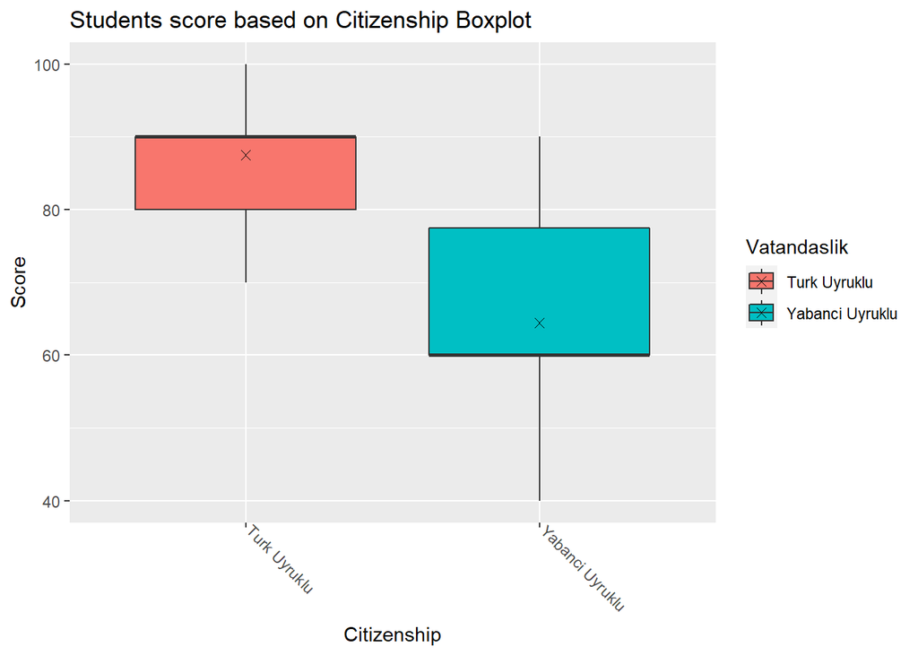

```r
ggplot(data=df, aes(x=Vatandaslik, y=Score, fill= Vatandaslik)) +
  geom_boxplot() +
  labs(title = "Students score based on Citizenship Boxplot", x="Citizenship", y="Score") +
  stat_summary(fun=mean, geom="point", shape=4, size=2) +
  theme(axis.text.x=element_text(angle=-45,hjust=0,vjust=0))
```

The boxplot shows students score is associated with citizenship.

#### Analyzing students date-of-birth

```r
# Extracting year from date
df$Dogum.Tarihi <- as.Date(df$Dogum.Tarihi, "%m/%d/%Y")
df$age <- as.numeric(format(df$Dogum.Tarihi, "%Y"))

df$age <- 2020 - df$age

age.df <- data.frame(table(df$age))
names(age.df) <- c("age", "freq")
age.df
```

```
##   age freq
## 1  21    7
## 2  22    4
## 3  23    8
## 4  24    5
## 5  25    3
## 6  26    1
## 7  27    1
## 8  28    1
```

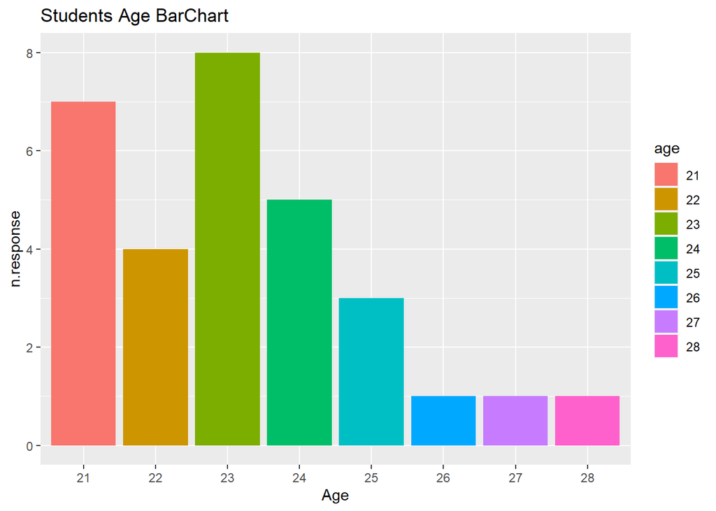

```r
ggplot(age.df, aes(x=age, y=freq, fill=age))+
  geom_bar(stat = "identity") +
  labs(title = "Students Age BarChart", x="Age", y="n.response")
```

The figure shows most of the students participated to quiz are between 21-25 years old.

#### Analyzing Score based on age

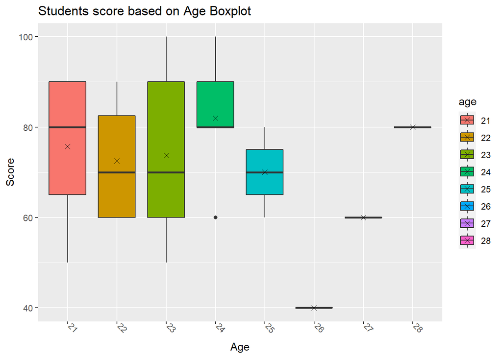

```r
df$age <- as.factor(df$age)
ggplot(data=df, aes(x=age, y=Score, fill= age)) +
  geom_boxplot() +
  labs(title = "Students score based on Age Boxplot", x="Age", y="Score") +
  stat_summary(fun=mean, geom="point", shape=4, size=2) +
  theme(axis.text.x=element_text(angle=-45,hjust=0,vjust=0))
```

```r
var(df[df$age=="27", 2])
```

```
## [1] NA
```

The boxplot indicates that the score of students with age 23 is very disperse. Also it indicates that the mean and median of students score with age 26 is less than the rest of students.

### The Google-Form beautiful and informative analysis graphs

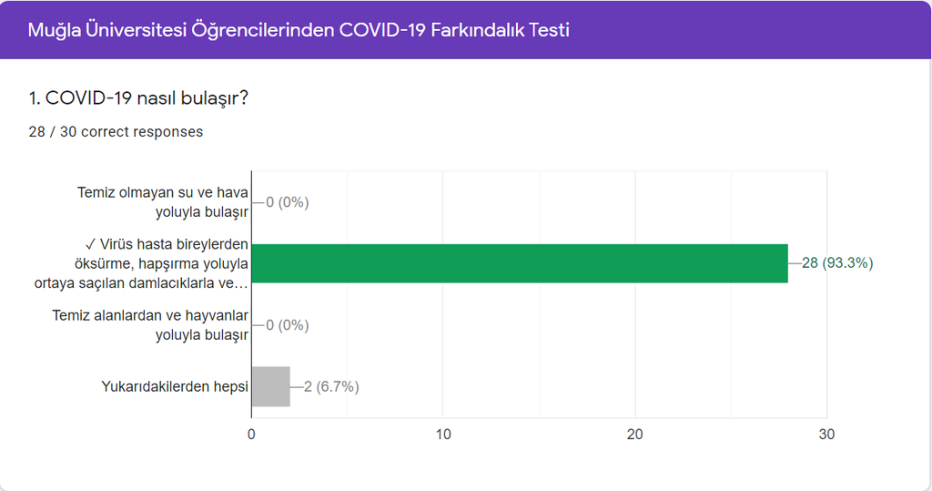

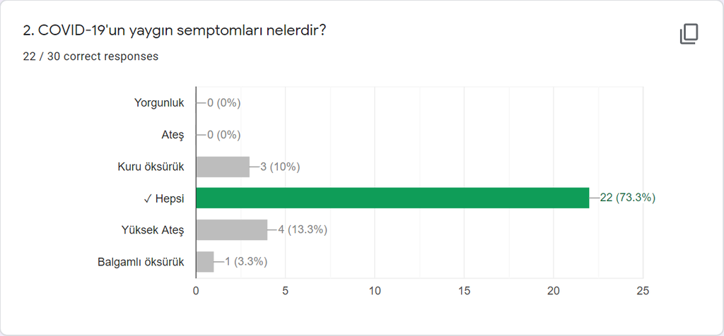

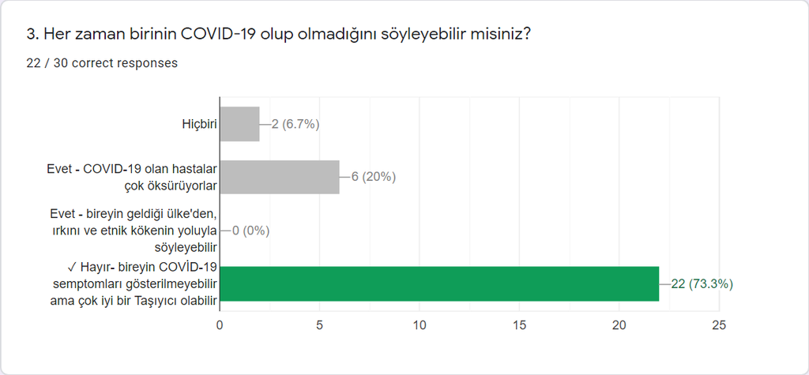

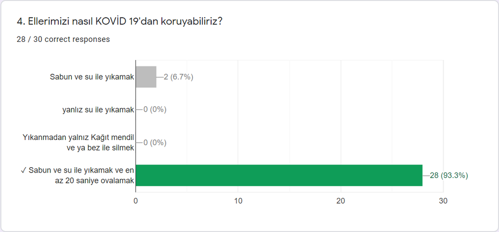

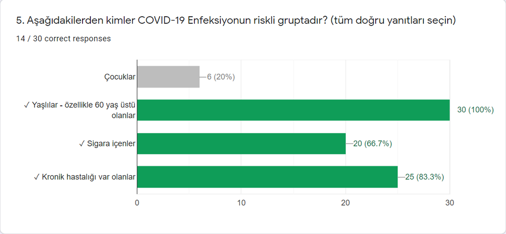

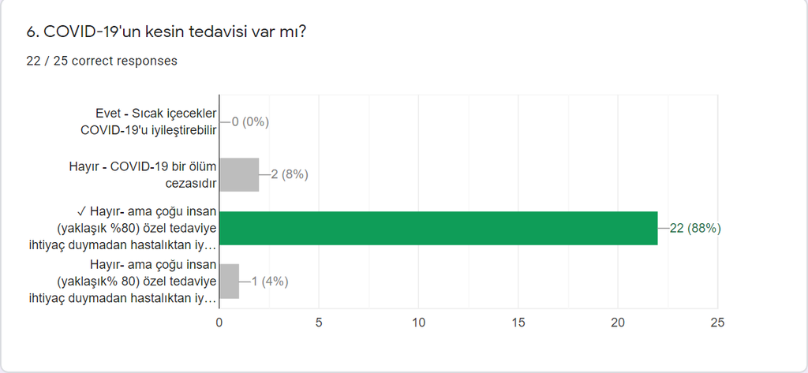

[figure not shown]

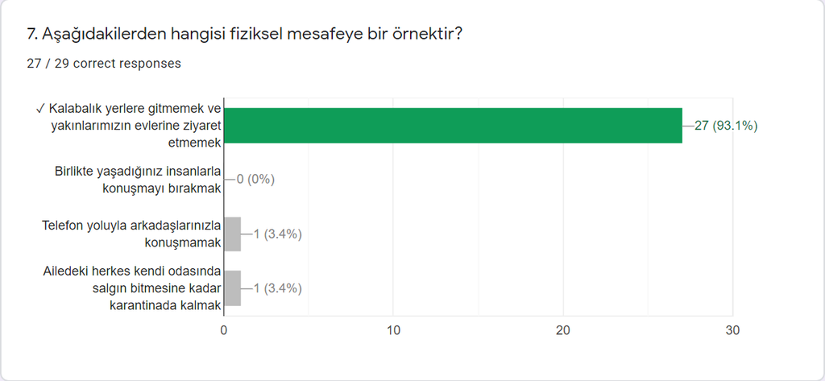

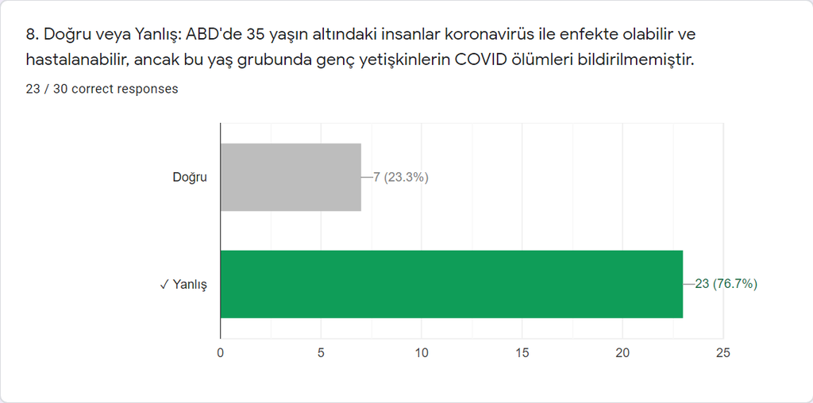

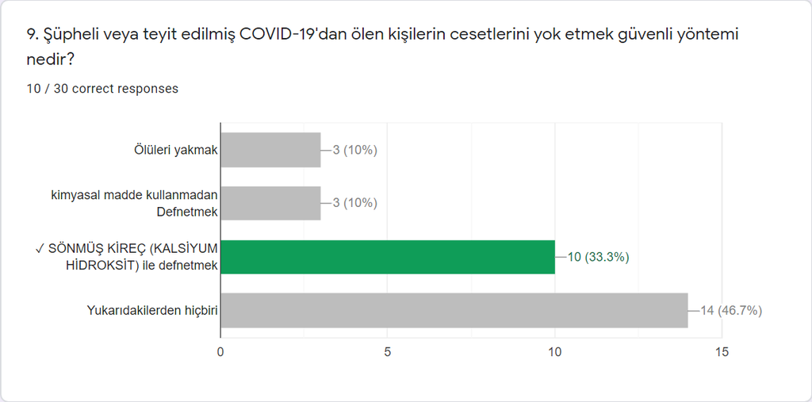

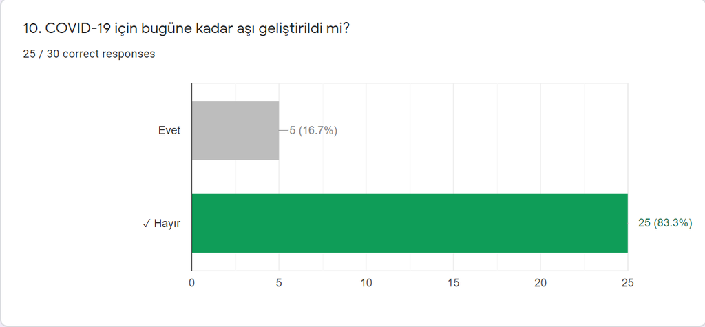

## Confidence intervals

### Q1:

Find confidence interval for score evaluating the differences based on gender. Use ggplot2 to plot the corresponding confidence intervals to support your evaluations.

Let’s start by calculating confidence interval for students score based on gender.

```r
males <- subset(df, Cinsiyet=="Erkek")
females <- subset(df, Cinsiyet=="Kadin")

# Calculating confidence interval for score of male students
x <- t.test(males$Score)$conf.int
x
```

```
## [1] 62.60731 76.52312
## attr(,"conf.level")
## [1] 0.95
```

The above output indicates that the true average of score for male students is between 62.61 and 76.52 with 95% confident.

```r
# calculating confidence interval for females score
y <- t.test(females$Score)$conf.int
y
```

```
## [1] 80.15168 94.13403
## attr(,"conf.level")
## [1] 0.95
```

Also the above output indicates that the true average of score for female students is between 80.15 and 94.13 with 95% confident.

To conclude, It looks there is no overlap between males and females score confidence interval and it’s a clue that the difference may be significant, but we cannot be sure. We must perform statistical test to draw a conclusion.

Here is how it looks like when we visualize it.

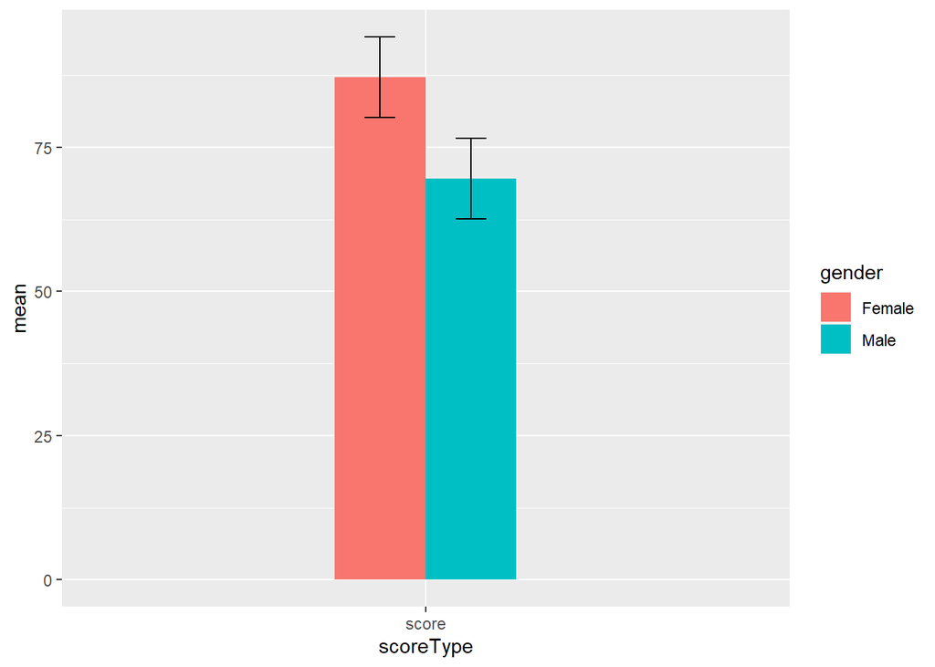

```r
students.score <- data.frame(gender="Male",
                                scoreType="score",
                                mean=mean(males$Score),
                                lower=x[1],
                                upper=x[2])

students.score <- rbind(students.score, data.frame(gender="Female",
                                scoreType="score",
                                mean=mean(females$Score),
                                lower=y[1],
                                upper=y[2]))

ggplot(students.score, aes(x=scoreType, y=mean, fill=gender)) +
  geom_bar(position="dodge", stat="identity", width = 0.3) +
  geom_errorbar(aes(ymin=lower, ymax=upper),
                width=.1, # Width of the error bars
                position=position_dodge(0.3))
```

### Q2:

Find confidence interval for score evaluating the differences based on citizenship. Use ggplot2 to plot the corresponding confidence interval to support your evaluations.

Here we will calculate confidence interval for students score based on citizenship.

```r
Turkish <- subset(df, Vatandaslik=="Turk Uyruklu")
foreigner <- subset(df, Vatandaslik=="Yabanci Uyruklu")

# Calculating confidence interval for score of Turkish students
x <- t.test(Turkish$Score)$conf.int
x
```

```
## [1] 81.99754 93.00246
## attr(,"conf.level")
## [1] 0.95
```

```r
# calculating confidence interval for score of foreigner-students
y <- t.test(foreigner$Score)$conf.int
y
```

```
## [1] 57.78960 71.09929
## attr(,"conf.level")
## [1] 0.95
```

To conclude, It looks there is no overlap between Turkish and foreigner score confidence interval and it’s a clue that the difference may be significant, but we cannot be sure. We must perform statistical test to draw a conclusion.

Here is how it looks like when we visualize it.

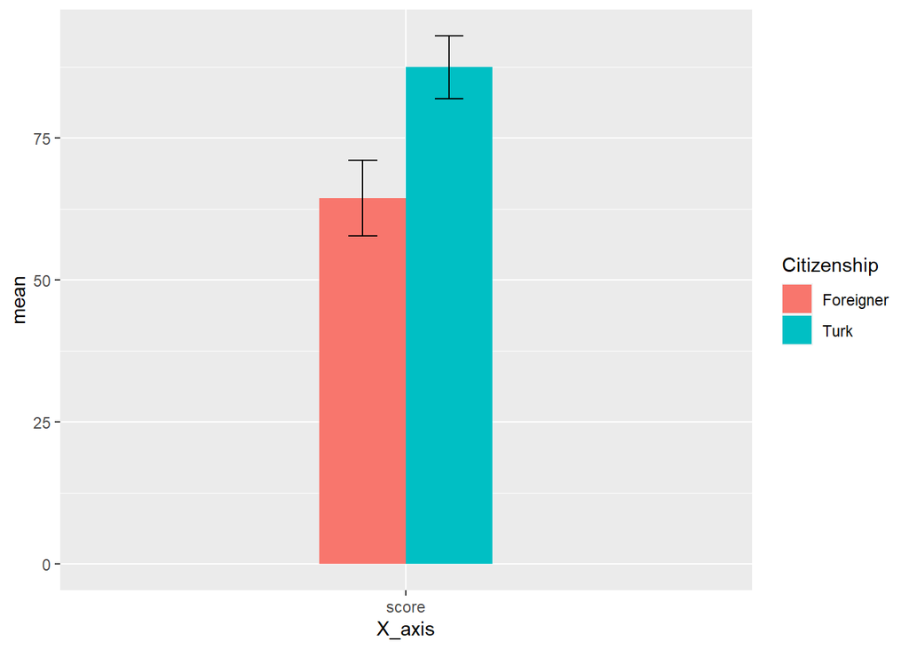

```r
students.score <- data.frame(Citizenship="Turk",
                                X_axis="score",
                                mean=mean(Turkish$Score),
                                lower=x[1],
                                upper=x[2])

students.score <- rbind(students.score, data.frame(Citizenship="Foreigner",
                                X_axis="score",
                                mean=mean(foreigner$Score),
                                lower=y[1],
                                upper=y[2]))

ggplot(students.score, aes(x=X_axis, y=mean, fill=Citizenship)) +
  geom_bar(position="dodge", stat="identity", width = 0.3) +
  geom_errorbar(aes(ymin=lower, ymax=upper),
                width=.1, # Width of the error bars
                position=position_dodge(0.3))
```

## Hypothesis testing

### ONE SAMPLE TEST

#### Q1: Create one sample hypothesis for mean of male students score and test it with 95% confidence level.

Let’s test that the true average of male students score is equal to 75, So the hypothesis is formulated as following:  
H0: mu = 75  
Ha: mu != 75

The data is not continues, but for the lack of continues data in our dataset, let’s assume the data is continues and we assume the sample is a simple random sample. As the sample size is not large enough, we will assess the normality. In order to assess normality of data, we can use qqplot and shapiro test.

```r
shapiro.test(males$Score)
```

```
##
##  Shapiro-Wilk normality test
##
## data:  males$Score
## W = 0.94132, p-value = 0.1918
```

As the p-value > 0.05, the null hypothesis is not rejected, so data is normally distributed.

Let’s visualize it using Q-Q Plot.

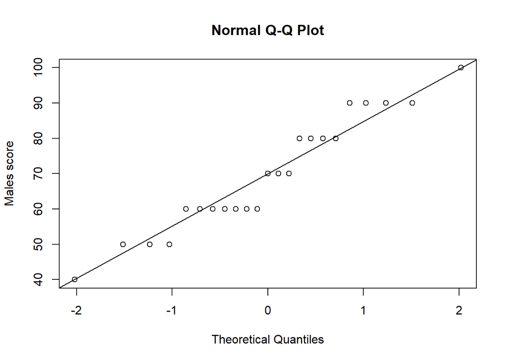

```r
qqnorm(males$Score, ylab = "Males score")
qqline(males$Score)
```

Now it is time to test the hypothesis.

```r
t.test(males$Score,
       alternative = "two.sided",
       mu=75,
       conf.level = 0.95)
```

```
##
##  One Sample t-test
##
## data:  males$Score
## t = -1.6199, df = 22, p-value = 0.1195
## alternative hypothesis: true mean is not equal to 75
## 95 percent confidence interval:
##  62.60731 76.52312
## sample estimates:
## mean of x
##  69.56522
```

## TWO SAMPLE TEST

### Q2: Are there significant difference between mean of male and female students score?

To start, it always helps to plot things!!!

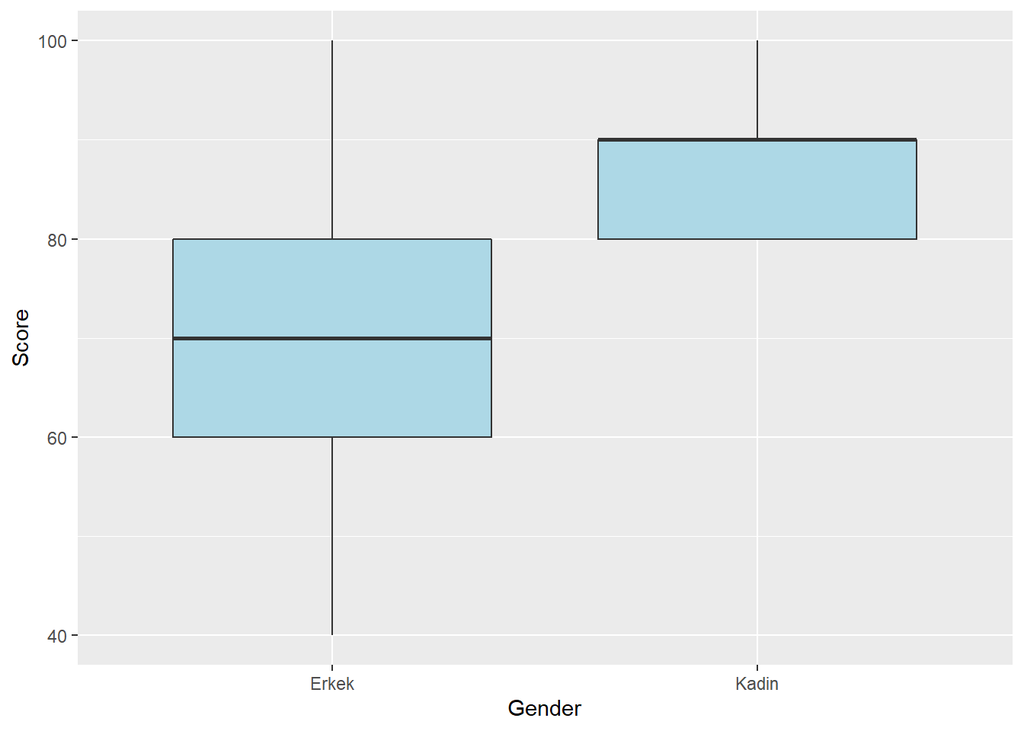

```r
# Create boxplot showing how score varies based on gender
qplot(x = Cinsiyet, y = Score,
      geom = "boxplot", data = df,
      xlab = "Gender",
      ylab = "Score",
      fill = I("lightblue"))
```

This plot suggests that score is associated with gender.

Let’s compute a summary table

```r
aggregate(Score ~ Cinsiyet,
          data = df,
          FUN = function(x) {c(mean = mean(x),
                               se = sd(x) / sqrt(length(x)))})
```

```
##   Cinsiyet Score.mean  Score.se
## 1    Erkek  69.565217  3.355030
## 2    Kadin  87.142857  2.857143
```

This difference is looking quite significant.

Let’s visualize it.

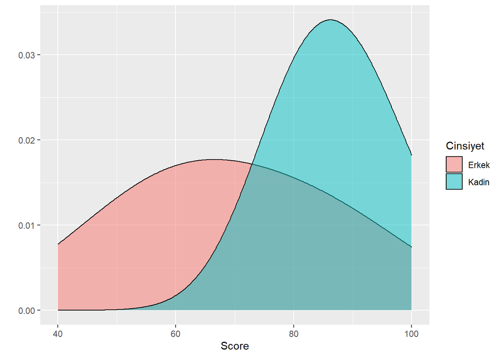

```r
# Density plots
qplot(fill = Cinsiyet,
      x = Score,
      data = df,
      geom = "density",
      alpha = I(0.5),
      adjust = 2
      )
```

Let’s check if the populations have the same variance.

```r
x <- subset(df, Cinsiyet=="Erkek")$Score
y <- subset(df, Cinsiyet=="Kadin")$Score
var.test(x, y)
```

```
##
##  F test to compare two variances
##
## data:  x and y
## F = 4.5306, num df = 22, denom df = 6, p-value = 0.06817
## alternative hypothesis: true ratio of variances is not equal to 1
## 95 percent confidence interval:
##   0.8813498 13.8394455
## sample estimates:
## ratio of variances
##           4.530632
```

As p-value > 0.05, the null hypothesis is not rejected and the variances are equal.

As the sample size is not large enough, we will assess the normality. We have already assess normality of male student scores and it was normal. So we will check normality just for female student scores. In order to assess normality of data, we can use qqplot and shapiro test.

```r
shapiro.test(females$Score)
```

```
##
##  Shapiro-Wilk normality test
##
## data:  females$Score
## W = 0.83338, p-value = 0.08614
```

As the p-value > 0.05, the null hypothesis is not rejected, so data is normally distributed.

Let’s visualize it using Q-Q Plot.

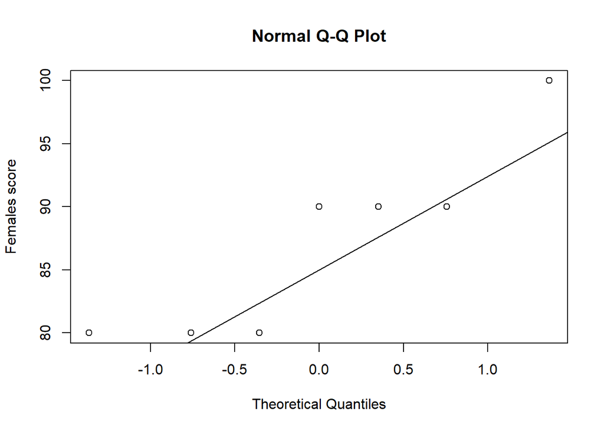

```r
qqnorm(females$Score, ylab = "Females score")
qqline(females$Score)
```

Although female student scores are not large enough and the data is not continues, it is hard to say it is normal or not. However, as it is mentioned in Instructions-for-Final-Project document we will assume the data is normal.

Checking assumptions:

- The two samples are random and independent.
- The sample size per gender is not large enough, but we assume the data are normal.
- The variances are equal.

```r
t.test(x=x, y=y, alternative = "two.sided", var.equal = TRUE,
       conf.level = 0.95)
```

```
##
##  Two Sample t-test
##
## data:  x and y
## t = -2.7729, df = 28, p-value = 0.009773
## alternative hypothesis: true difference in means is not equal to 0
## 95 percent confidence interval:
##  -30.562875  -4.592404
## sample estimates:
## mean of x mean of y
##  69.56522  87.14286
```

To conclude, as p-value < 0.05, the null hypothesis is rejected. We can conclude that there is statistically significant difference between male and female students score.

### Q3: Are there significant difference between mean of Turkish and foreigner students scores?

Again we start by plotting!!!

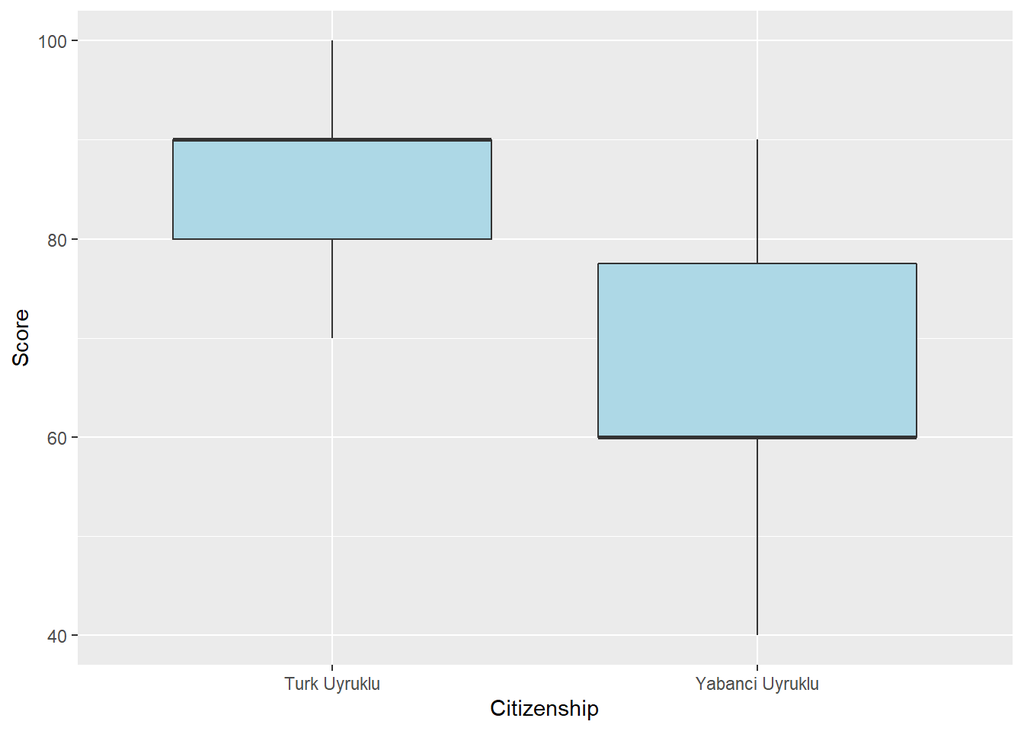

```r
# Create boxplot showing how score varies based on citizenship
qplot(x = Vatandaslik, y = Score,
      geom = "boxplot", data = df,
      xlab = "Citizenship",
      ylab = "Score",
      fill = I("lightblue"))
```

This plot suggests that score is associated with Citizenship.

Let’s compute a summary table

```r
aggregate(Score ~ Vatandaslik,
          data = df,
          FUN = function(x) {c(mean = mean(x),
                               se = sd(x) / sqrt(length(x)))})
```

```
##       Vatandaslik Score.mean Score.se
## 1    Turk Uyruklu   87.50000  2.50000
## 2 Yabanci Uyruklu   64.44444  3.15423
```

This difference is looking quite significant.

Let’s visualize it.

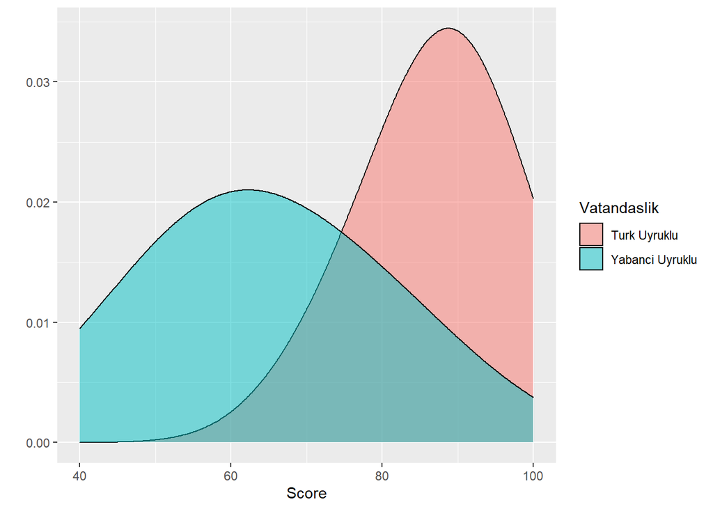

```r
# Density plots
qplot(fill = Vatandaslik,
      x = Score,
      data = df,
      geom = "density",
      alpha = I(0.5),
      adjust = 2
      )
```

Let’s check if the populations have the same variance.

```r
x <- subset(df, Vatandaslik=="Turk Uyruklu")$Score
y <- subset(df, Vatandaslik=="Yabanci Uyruklu")$Score
var.test(x, y)
```

```
##
##  F test to compare two variances
##
## data:  x and y
## F = 0.4188, num df = 11, denom df = 17, p-value = 0.1454
## alternative hypothesis: true ratio of variances is not equal to 1
## 95 percent confidence interval:
##  0.1459402 1.3743361
## sample estimates:
## ratio of variances
##          0.4187956
```

As p-value > 0.05, the null hypothesis is not rejected and the variances are equal.

As the sample size is not large enough, we will assess the normality. In order to assess normality of data, we can use qqplot and shapiro test.

```r
shapiro.test(Turkish$Score)
```

```
##
##  Shapiro-Wilk normality test
##
## data:  Turkish$Score
## W = 0.8842, p-value = 0.09922
```

As the p-value > 0.05, the null hypothesis is not rejected, so data is normally distributed.

Let’s visualize it using Q-Q Plot.

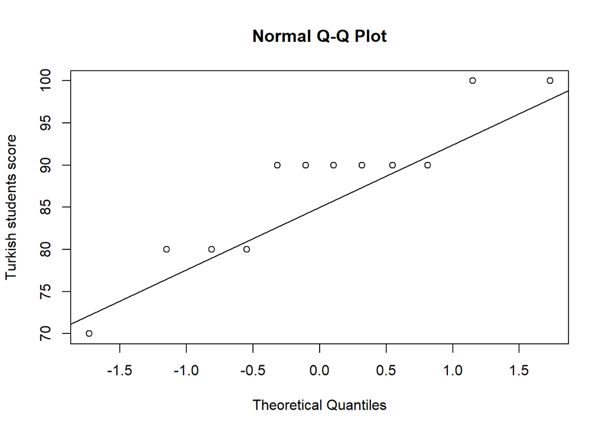

```r
qqnorm(Turkish$Score, ylab = "Turkish students score")
qqline(Turkish$Score)
```

Although Turkish-student scores are not large enough and the data is not continues, it is hard to say it is normal or not. But, again we assume it is normal for the reason we mentioned above. Now, we will check normality for foreigner-students scores.

```r
shapiro.test(foreigner$Score)
```

```
##
##  Shapiro-Wilk normality test
##
## data:  foreigner$Score
## W = 0.92711, p-value = 0.1727
```

As the p-value > 0.05, the null hypothesis is not rejected, so data is normally distributed.

Let’s visualize it using Q-Q Plot.

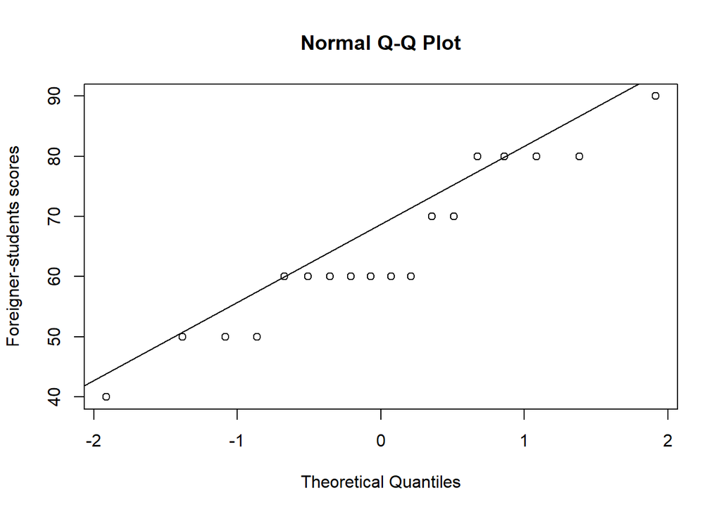

```r
qqnorm(foreigner$Score, ylab = "Foreigner-students scores")
qqline(foreigner$Score)
```

Foreigner-students scores are not large enough and the data is not continues, it is hard to say it is normal or not. However, as it is mentioned in Instructions-for-Final-Project document we will assume the data is normal.

Checking assumptions:

- The two samples are random and independent.
- The sample size per citizenship is not large enough, but we assume the data are normal.
- The variances are equal.

```r
t.test(x=x, y=y, alternative = "two.sided", var.equal = TRUE,
       conf.level = 0.95)
```

```
##
##  Two Sample t-test
##
## data:  x and y
## t = 5.2626, df = 28, p-value = 1.353e-05
## alternative hypothesis: true difference in means is not equal to 0
## 95 percent confidence interval:
##  14.08136 32.02975
## sample estimates:
## mean of x mean of y
##  87.50000  64.44444
```

To conclude, as p-value < 0.05, the null hypothesis is rejected. We can conclude that there is statistically significant difference between Turkish and foreigner students score.

## ANOVA

### Q1: Are there significant differences between mean of different classes score?

```r
data <- df[, c(2, 6)]
names(data) <- c("score", "class")

# Show a random sample
set.seed(1234)
dplyr::sample_n(data, 10)
```

```
##    score class
## 1     80     2
## 2     60     1
## 3     80     2
## 4     40     4
## 5     50     3
## 6     90     2
## 7     90     4
## 8     70     4
## 9     80     3
## 10    90     2
```

```r
# Show the levels
levels(data$class)
```

```
## [1] "1" "2" "3" "4"
```

```r
# Compute summary statistics by class - count, mean, sd:
group_by(data, class) %>%
  summarise(
    count = n(),
    mean = mean(score, na.rm = TRUE),
    sd = sd(score, na.rm = TRUE)
  )
```

```
## # A tibble: 4 x 4
##   class count  mean    sd
##   <fct> <int> <dbl> <dbl>
## 1 1         3  56.7  5.77
## 2 2        10  79   11.0
## 3 3        11  76.4 19.1
## 4 4         6  68.3 17.2
```

The Hypothesis is as following:  
H0: mu1=mu2=mu3=mu4  
Ha: At least one of them is different

#### 1) Visualization

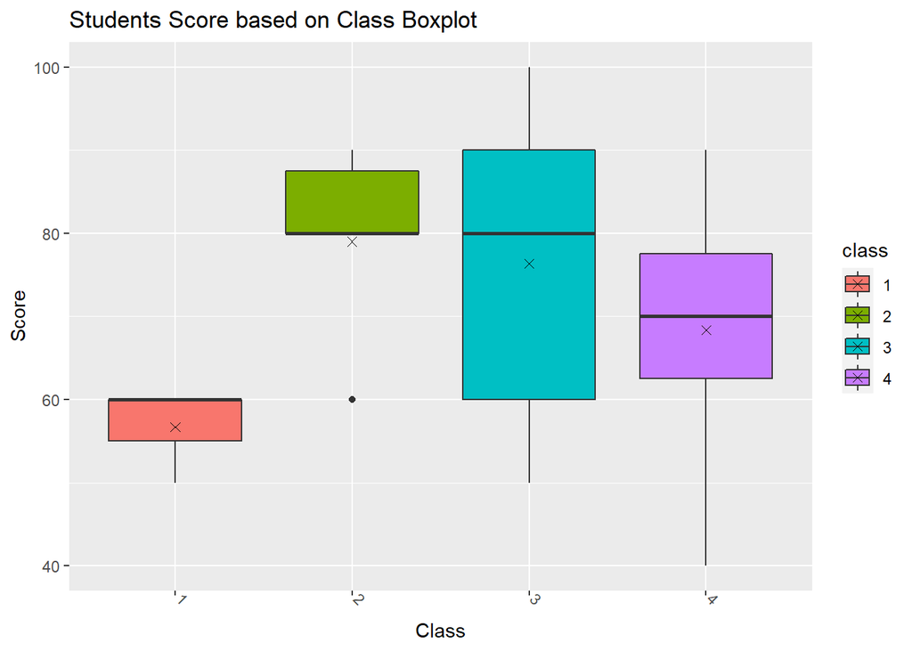

```r
ggplot(data=data, aes(x=class, y=score, fill= class)) +
  geom_boxplot() +
  labs(title = "Students Score based on Class Boxplot", x = "Class", y="Score") +
  stat_summary(fun=mean, geom="point", shape=4, size=2) +
  theme(axis.text.x=element_text(angle=-45,hjust=0,vjust=0))
```